# Assignment 5 - Confirmatory Factor Analysis

```r
library(lavaan)
#library(lavaanPlot)
library(tidyverse)
library(apaTables)
library(corrplot)
```

```r
#setwd("C:/Users/Administrator/Google Drive/courses/Structural_Equation_Modeling/assignments/assignment_04/")
setwd("~/Google_Drive/courses/Structural_Equation_Modeling/assignments/assignment_04/")
getwd()
```

```
[1] "/Users/haroonpopal/Google_Drive/courses/Structural_Equation_Modeling/assignments/assignment_04"
```

# The Dimensional Representation of Social Relationships

### Import and configure relationship dimension dataset

This dataset was collected via Amazon Mechanical Turk (mturk). The dataset contains ratings of 159 social relationships (i.e. parent - child, parent - teenager, husband - wife, etc.), on 30 dimensions. Participants were asked to rate each given relationship, on each of the given dimensions (i.e. how related is this relationship to this dimension).

The dimensions were derived from a literature search, where each source presented 2-6 dimensions that they believed could explain all of the variance between people’s conceptual understanding of social relationships. We collected all of these dimensions to create our list of 30 total dimensions.

```r
dim_rel <- read.csv("dim_rel.csv")
dim_rel <- as.data.frame(t(dim_rel))
#Provide names to the variables
names(dim_rel) <- as.character(unlist(dim_rel[1,]))
dim_rel = dim_rel[-1, ]
#rownames(dim_rel) <- NULL
dim_rel <- apply(dim_rel, 2,            # Specify own function within apply
                    function(x) as.numeric(as.character(x)))
colnames(dim_rel) <- sub(" ", "_", colnames(dim_rel))
colnames(dim_rel)
```

```
 [1] "Negotiation"                         "Equality"
 [3] "Communal_Sharing"                    "Spatial_Distance"
 [5] "Endurance"                           "Synchronicity"
 [7] "Activity_Intensity"                  "Importance_for society"
 [9] "Activeness"                          "Uniqueness"
[11] "Goods_Exchange"                      "Attachment"
[13] "Love_Expression"                     "Socioemotional"
[15] "Occupational"                        "Mating"
[17] "Information_Exchange"                "Conflict"
[19] "Valence_Evaluation"                  "Coercion"
[21] "Affiliation/Coalition"               "Service_Exchange"
[23] "Visibility"                          "Strategic"
[25] "Formality_and Regulation"            "Concreteness"
[27] "Expected_Reciprocity"                "Importance_for individuals involved"
[29] "Intimacy"                            "Money_Exchange"
```

## Print full correlation matrix with means and standard deviations

```r
apa.cor.table(dim_rel)
```

```
Means, standard deviations, and correlations with confidence intervals


  Variable                                M     SD    1           2            3            4
  1. Negotiation                          47.39 18.48

  2. Equality                             44.59 31.41 .22**
                                                      [.06, .36]

  3. Communal_Sharing                     46.85 28.99 -.06        .51**
                                                      [-.22, .09] [.38, .62]

  4. Spatial_Distance                     67.50 22.18 .21**       -.12         .17*
                                                      [.06, .36]  [-.27, .04]  [.02, .32]

  5. Endurance                            52.71 27.34 -.03        .33**        .81**        .11
                                                      [-.18, .13] [.18, .46]   [.75, .86]   [-.05, .26]

  6. Synchronicity                        70.04 15.98 .30**       -.02         .11          .79**
                                                      [.15, .43]  [-.18, .13]  [-.05, .26]  [.72, .84]

  7. Activity_Intensity                   55.51 23.25 .10         .20**        .72**        .47**
                                                      [-.06, .25] [.05, .35]   [.63, .78]   [.34, .58]

  8. Importance_for society               53.52 21.89 .07         -.36**       -.05         .29**
                                                      [-.09, .22] [-.49, -.22] [-.20, .11]  [.14, .42]

  9. Activeness                           68.68 17.95 .34**       .03          .37**        .72**
                                                      [.19, .47]  [-.13, .19]  [.23, .50]   [.64, .79]

  10. Uniqueness                          52.56 23.12 .12         .18*         .58**        .23**
                                                      [-.04, .27] [.03, .33]   [.47, .68]   [.07, .37]

  11. Goods_Exchange                      34.76 19.10 .44**       -.09         -.24**       .23**
                                                      [.31, .56]  [-.24, .06]  [-.38, -.09] [.07, .37]
  5            6           7            8            9            10           11           12




```

[output cut: 115 more lines]

```








 [ reached getOption("max.print") -- omitted 58 rows ]

Note. M and SD are used to represent mean and standard deviation, respectively.
Values in square brackets indicate the 95% confidence interval.
The confidence interval is a plausible range of population correlations
that could have caused the sample correlation (Cumming, 2014).
* indicates p < .05. ** indicates p < .01.
```

This doesn’t print things in the best format, so I am printing a correlation matrix figure below.

### Correlation Matrix Figure

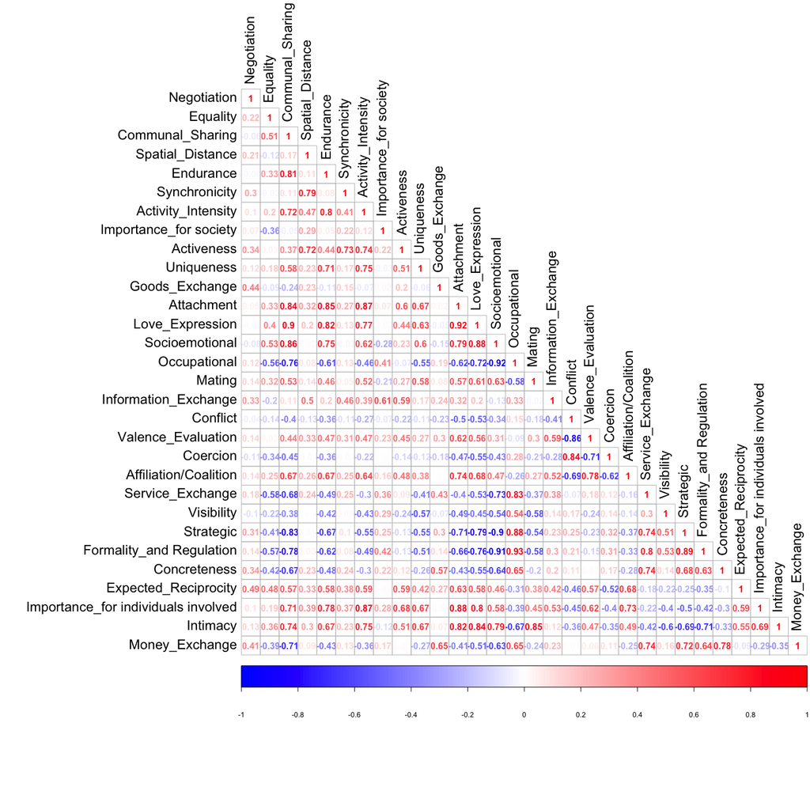

```r
#apa.cor.table(dim_rel)
cor_mtx <- cor(dim_rel) # get correlations
corrplot(cor_mtx, method = "number", type = "lower", number.cex = 1, tl.col = "black", tl.cex = 1.5, col = colorRampPalette(c("blue","white","red"))(200))
```

## Initial model

In this model, we hypothesize that the communal sharing, endurance, attachment, and love expression dimensions are part of a broader construct, the socioemotional dimension. The socioemotional dimension was derived in the original paper by a factor analysis, and so in this analysis, we would like to see if this is a latent factor that captures some of the variance of the other dimensions, from other sources.

```r
dim_rel_m1 <- 'Socioemotional =~ NA*Communal_Sharing + Endurance + Attachment + Love_Expression
           Socioemotional ~~ 1*Socioemotional'
#Fit initial model
dim_rel_m1_fit <- sem(dim_rel_m1, dim_rel)
#Examine initial summary data
summary(dim_rel_m1_fit)
```

```
lavaan 0.6-5 ended normally after 28 iterations

  Estimator                                         ML
  Optimization method                           NLMINB
  Number of free parameters                          8

  Number of observations                           159

Model Test User Model:

  Test statistic                                20.895
  Degrees of freedom                                 2
  P-value (Chi-square)                           0.000

Parameter Estimates:

  Information                                 Expected
  Information saturated (h1) model          Structured
  Standard errors                             Standard

Latent Variables:
                    Estimate  Std.Err  z-value  P(>|z|)
  Socioemotional =~
    Communal_Shrng    26.376    1.761   14.975    0.000
    Endurance         23.620    1.721   13.727    0.000
    Attachment        25.894    1.614   16.040    0.000
    Love_Expressin    31.235    1.865   16.749    0.000

Variances:
                   Estimate  Std.Err  z-value  P(>|z|)
    Socioemotional    1.000
   .Communal_Shrng  139.530   18.645    7.484    0.000
   .Endurance       185.115   22.911    8.080    0.000
   .Attachment       74.393   12.205    6.095    0.000
   .Love_Expressin   58.713   14.171    4.143    0.000
```

### Multiple steps to get smaller amount of information

```r
dim_rel_m1_fit_ab <- data.frame(fitMeasures(dim_rel_m1_fit))
dim_rel_m1_fit_ab <- round(dim_rel_m1_fit_ab, 3)
dim_rel_m1_fit_ab$index <- row.names(dim_rel_m1_fit_ab)
```

### Retaining only the commonly used indices; the last ‘[c(2,1)]’ just changes the order of the columns

```r
dim_rel_m1_fit_ab <- dim_rel_m1_fit_ab[dim_rel_m1_fit_ab$index %in% c("npar", "chisq", "df", "pvalue",
                                                    "rmsea", "rmsea.ci.lower", "rmsea.ci.upper",
                                                    "rmsea.pvalue", "cfi", "tli", "aic", "bic", "bic2"),][c(2,1)]
dim_rel_m1_fit_ab
```

|  | index | fitMeasures.dim_rel_m1_fit. |
| --- | --- | --- |
| npar | npar | 8.000 |
| chisq | chisq | 20.895 |
| df | df | 2.000 |
| pvalue | pvalue | 0.000 |
| cfi | cfi | 0.976 |
| tli | tli | 0.927 |
| aic | aic | 5332.563 |
| bic | bic | 5357.115 |
| bic2 | bic2 | 5331.790 |
| rmsea | rmsea | 0.244 |

[output cut: 3 more lines]

CFI is good as it is above 0.95. TLI is also good as it is high, but not great (below 0.95). AIC and BIC are good because they are very high. The rmsea is very high, and the p-value is significant, is significant, indicating that there is little chance the rmsea is below 0.05 The model fits somewhat well.